# SDC-Report

## Input Data

The data set consists of **4580** observations and was imported from **testdata**.

## Information on selected important (key) variables

- **Categorical key variable(s)**: *urbrur* | *water* | *relat* | *sex*
- **Continuous key variable(s)**: *income* | *savings*
- **Weight variable**: *sampling_weight*
- **householdID**: *ori_hid*
- **strataVariable(s)**: *not defined*

## Modifications

- Modifications on categorical key variables: **FALSE**
- Modifications on continuous key variables: **TRUE**
- Modifications using PRAM: **FALSE**
- Local suppressions: **TRUE**

## Disclosure risk:

### Frequency Analysis for Categorical Key Variables

#### Number of observations violating

- **2-Anonymity:** 0 (original dataset: 24)
- **3-Anonymity:** 0 (original dataset: 44)

#### Percentage of observations violating

- **2-Anonymity:** 0.000% (original dataset: 0.524%)
- **3-Anonymity:** 0.000% (original dataset: 0.961%)

### Disclosure Risk for Categorical Variables

Expected Percentage of Reidentifications:

- **modified data**: 0.017% (~ 0.789 observations)
- **original data**: 0.049% (~ 2.251 observations)

#### 10 combinations of categories with highest risks

| urbrur | water | relat | sex | risk | fk | Fk | hier_risk |
| --- | --- | --- | --- | --- | --- | --- | --- |
| 2 | 1 | 5 | 1 | 0.005 | 3 | 300 | 0.0072039 |
| 2 | 1 | 6 | 1 | 0.005 | 3 | 300 | 0.0055579 |
| 1 | 4 | 4 | 2 | 0.005 | 3 | 300 | 0.0123123 |
| 1 | 4 | 7 | 2 | 0.005 | 3 | 300 | 0.0062471 |
| 2 | 3 | 4 | 2 | 0.003 | 4 | 400 | 0.0057059 |
| 2 | 6 | 1 | 1 | 0.003 | 4 | 400 | 0.0119982 |
| 1 | 4 | 5 | 2 | 0.003 | 4 | 400 | 0.0123123 |
| 2 | 9 | 1 | 2 | 0.003 | 4 | 400 | 0.0033223 |
| 2 | 1 | 7 | 2 | 0.002 | 5 | 500 | 0.0071899 |
| 2 | 3 | 9 | 1 | 0.002 | 5 | 500 | 0.0027558 |

### Disclosure Risk Continuous Scaled Variables

The (distance-based) disclosure risk for continous key variables is between 0.000% and 99.913% in the modified data.

In the original data, the risk is assumed to be approximately 100.000%.

### Hierarchical risk

- **modified data**: 4.120 (0.090%)
- **original data**: 11.682 (0.255%)

## Data Utility

### Frequencies Categorical Key Variables:

#### Variable: *urbrur*

| Categories | Original data | Modified data |
| --- | --- | --- |
| 1 | 646 | 646 |
| 2 | 3934 | 3934 |

#### Variable: *water*

| Categories | Original data | Modified data |
| --- | --- | --- |
| 1 | 600 | 600 |
| 2 | 66 | 66 |
| 3 | 1478 | 1478 |
| 4 | 1755 | 1755 |
| 5 | 584 | 583 |
| 6 | 26 | 26 |
| 7 | 36 | 36 |
| 9 | 35 | 35 |
| NA | NA | 1 |

#### Variable: *relat*

| Categories | Original data | Modified data |
| --- | --- | --- |
| 1 | 1000 | 998 |
| 2 | 805 | 803 |
| 3 | 2576 | 2576 |
| 4 | 15 | 13 |
| 5 | 63 | 50 |
| 6 | 36 | 28 |
| 7 | 75 | 66 |
| 8 | 1 | NA |
| 9 | 9 | 3 |
| NA | NA | 43 |

#### Variable: *sex*

| Categories | Original data | Modified data |
| --- | --- | --- |
| 1 | 2296 | 2296 |
| 2 | 2284 | 2284 |

### Local Suppressions

The table below shows for each categorical key variable the number (1st row) and the percentages (2nd row) of suppressed cells.

[output not shown]

### Data Utility of Continuous Scaled Key Variables

#### Univariate summary of variable *income*

|  | Original | Modified | Difference |
| --- | --- | --- | --- |
| Min. | 2.897484e+03 | 207653 | -2.047555e+05 |
| 1st Qu. | 2.510000e+07 | 25000000 | 1.000000e+05 |
| Median | 5.075000e+07 | 50666667 | 8.333330e+04 |
| Mean | 5.011569e+07 | 50115690 | 3.485200e-03 |
| 3rd Qu. | 7.500000e+07 | 75100000 | -1.000000e+05 |
| Max. | 1.000000e+08 | 99766667 | 2.333333e+05 |

#### Univariate summary of variable *savings*

|  | Original | Modified | Difference |
| --- | --- | --- | --- |
| Min. | 2974.644 | 32838.1 | -2.986346e+04 |
| 1st Qu. | 2434822.750 | 2418011.3 | 1.681145e+04 |
| Median | 4982921.000 | 4983819.0 | -8.980000e+02 |
| Mean | 4964039.243 | 4964039.2 | 4.334540e-02 |
| 3rd Qu. | 7487258.000 | 7475125.3 | 1.213270e+04 |
| Max. | 9997808.000 | 9970270.0 | 2.753800e+04 |

#### Information Loss Criteria

- **Criteria IL1:** 75004.008%
- **Difference of Eigenvalues in modified data:** 0.001% (0.00% in original data)

#### Boxplot of Differences

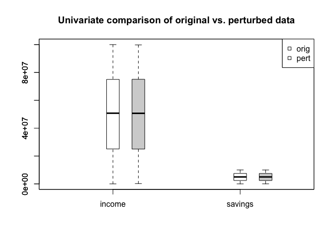

## Session-Info

### About the R-Version

- **Version**: R version 3.6.0 (2019-04-26)
- **Platform**: x86_64-apple-darwin15.6.0

### Locales

*en_US.UTF-8/en_US.UTF-8/en_US.UTF-8/C/en_US.UTF-8/en_US.UTF-8*

### Attached base packages

*grid* | *stats* | *graphics* | *grDevices* | *utils* | *datasets* | *methods* | *base*

### Other attached packages

*data.table (1.12.2)* | *shinyBS (0.61)* | *DT (0.5)* | *haven (2.1.0)* | *rhandsontable (0.3.7)* | *shiny (1.3.2)* | *sdcMicro (5.3.0)*

### Packages loaded via Namespace (but not attached)

*vcd (1.4-4)* | *Rcpp (1.0.1)* | *lattice (0.20-38)* | *zoo (1.8-5)* | *class (7.3-15)* | *lmtest (0.9-37)* | *assertthat (0.2.1)* | *digest (0.6.18)* | *mime (0.6)* | *VIM (4.8.0)* | *R6 (2.4.0)* | *ranger (0.11.2)* | *cellranger (1.1.0)* | *plyr (1.8.4)* | *evaluate (0.13)* | *e1071 (1.7-1)* | *ggplot2 (3.1.1)* | *pillar (1.3.1)* | *rlang (0.3.4)* | *lazyeval (0.2.2)* | *curl (3.3)* | *readxl (1.3.1)* | *rstudioapi (0.10)* | *car (3.0-2)* | *Matrix (1.2-17)* | *rmarkdown (1.12)* | *sets (1.0-18)* | *foreign (0.8-71)* | *htmlwidgets (1.3)* | *munsell (0.5.0)* | *compiler (3.6.0)* | *httpuv (1.5.1)* | *xfun (0.6)* | *pkgconfig (2.0.2)* | *htmltools (0.3.6)* | *nnet (7.3-12)* | *tidyselect (0.2.5)* | *tibble (2.1.1)* | *rio (0.5.16)* | *crayon (1.3.4)* | *dplyr (0.8.0.1)* | *laeken (0.5.0)* | *later (0.8.0)* | *MASS (7.3-51.4)* | *jsonlite (1.6)* | *xtable (1.8-4)* | *gtable (0.3.0)* | *magrittr (1.5)* | *scales (1.0.0)* | *zip (2.0.1)* | *carData (3.0-2)* | *promises (1.0.1)* | *sp (1.3-1)* | *robustbase (0.93-4)* | *boot (1.3-22)* | *openxlsx (4.1.0)* | *tools (3.6.0)* | *forcats (0.4.0)* | *glue (1.3.1)* | *DEoptimR (1.0-8)* | *purrr (0.3.2)* | *crosstalk (1.0.0)* | *prettydoc (0.2.1)* | *hms (0.4.2)* | *yaml (2.2.0)* | *abind (1.4-5)* | *colorspace (1.4-1)* | *cluster (2.0.8)* | *knitr (1.22)*

# Disclaimer

**R**-Package [**sdcMicro**](https://cran.r-project.org/web/packages/sdcMicro/) is actively developed and maintained by [**www.statistik.at**](http://www.statistik.at) and [**www.data-analysis.at**](http://www.data-analysis.at).

Please use the issue-tracker on *github* to report any issues:

- [**Issue-Tracker for sdcMicro**](https://github.com/alexkowa/sdcMicro/issues)

This report was generated on Thu, 09/05/2019 at 16:14:05.